# STT 301: dplyr

Rellika Kisyula

October 22, 2018

## Introduction

Learning Objectives

- `dplyr` package
  - `filter()`
  - `arrange()`
  - `select()`
  - `mutate()`
  - `summarize()`
  - `group_by()`

This document is adapted from the introductory `dplyr` vignette, which is available at https://cran.r-project.org/web/packages/dplyr/vignettes/introduction.html.

We will use the data frame `flights` which is included in the `nycflights13` package. Load both the `dplyr` package and the `nycflights13` package. If you haven’t yet installed one or both of these packages, you’ll have to do that first. In your console window type `install.packages("dplyr")` and `install.packages("nycflights13")` if needed.

Now, load the libraries.

```r
library(dplyr)
library(nycflights13)
```

## `flights`

First let’s look at the data frame `flights`. Type `?flights` in your console to see the variables along with a brief description. The below code would be a bad idea if `flights` were an ordinary data frame, but it is a `tbl_df` object which has more intelligent display options. Never show/print a large data frame in your R Markdown file.

```r
flights
```

```
# A tibble: 336,776 x 19
    year month   day dep_time sched_dep_time dep_delay arr_time
   <int> <int> <int>    <int>          <int>     <dbl>    <int>
 1  2013     1     1      517            515         2      830
 2  2013     1     1      533            529         4      850
 3  2013     1     1      542            540         2      923
 4  2013     1     1      544            545        -1     1004
 5  2013     1     1      554            600        -6      812
 6  2013     1     1      554            558        -4      740
 7  2013     1     1      555            600        -5      913
 8  2013     1     1      557            600        -3      709
 9  2013     1     1      557            600        -3      838
10  2013     1     1      558            600        -2      753
# ... with 336,766 more rows, and 12 more variables: sched_arr_time <int>,
#   arr_delay <dbl>, carrier <chr>, flight <int>, tailnum <chr>,
#   origin <chr>, dest <chr>, air_time <dbl>, distance <dbl>, hour <dbl>,
#   minute <dbl>, time_hour <dttm>
```

## `print` and `glimpse`

What if we want to see more (or less) than 10 rows of `flights` or want to see all the variables? To specify the number of rows displayed we can use a print statement.

```r
print(flights, n = 20)
```

```
# A tibble: 336,776 x 19
    year month   day dep_time sched_dep_time dep_delay arr_time
   <int> <int> <int>    <int>          <int>     <dbl>    <int>
 1  2013     1     1      517            515         2      830
 2  2013     1     1      533            529         4      850
 3  2013     1     1      542            540         2      923
 4  2013     1     1      544            545        -1     1004
 5  2013     1     1      554            600        -6      812
 6  2013     1     1      554            558        -4      740
 7  2013     1     1      555            600        -5      913
 8  2013     1     1      557            600        -3      709
 9  2013     1     1      557            600        -3      838
10  2013     1     1      558            600        -2      753
11  2013     1     1      558            600        -2      849
12  2013     1     1      558            600        -2      853
13  2013     1     1      558            600        -2      924
14  2013     1     1      558            600        -2      923
15  2013     1     1      559            600        -1      941
16  2013     1     1      559            559         0      702
17  2013     1     1      559            600        -1      854
18  2013     1     1      600            600         0      851
19  2013     1     1      600            600         0      837
20  2013     1     1      601            600         1      844
# ... with 3.368e+05 more rows, and 12 more variables:
#   sched_arr_time <int>, arr_delay <dbl>, carrier <chr>, flight <int>,
#   tailnum <chr>, origin <chr>, dest <chr>, air_time <dbl>,
#   distance <dbl>, hour <dbl>, minute <dbl>, time_hour <dttm>
```

To see all the variables, use `glimpse`.

```r
glimpse(flights)
```

```
Observations: 336,776
Variables: 19
$ year           <int> 2013, 2013, 2013, 2013, 2013, 2013, 2013, 2013,...
$ month          <int> 1, 1, 1, 1, 1, 1, 1, 1, 1, 1, 1, 1, 1, 1, 1, 1,...
$ day            <int> 1, 1, 1, 1, 1, 1, 1, 1, 1, 1, 1, 1, 1, 1, 1, 1,...
$ dep_time       <int> 517, 533, 542, 544, 554, 554, 555, 557, 557, 55...
$ sched_dep_time <int> 515, 529, 540, 545, 600, 558, 600, 600, 600, 60...
$ dep_delay      <dbl> 2, 4, 2, -1, -6, -4, -5, -3, -3, -2, -2, -2, -2...
$ arr_time       <int> 830, 850, 923, 1004, 812, 740, 913, 709, 838, 7...
$ sched_arr_time <int> 819, 830, 850, 1022, 837, 728, 854, 723, 846, 7...
$ arr_delay      <dbl> 11, 20, 33, -18, -25, 12, 19, -14, -8, 8, -2, -...
$ carrier        <chr> "UA", "UA", "AA", "B6", "DL", "UA", "B6", "EV",...
$ flight         <int> 1545, 1714, 1141, 725, 461, 1696, 507, 5708, 79...
$ tailnum        <chr> "N14228", "N24211", "N619AA", "N804JB", "N668DN...
$ origin         <chr> "EWR", "LGA", "JFK", "JFK", "LGA", "EWR", "EWR"...
$ dest           <chr> "IAH", "IAH", "MIA", "BQN", "ATL", "ORD", "FLL"...
$ air_time       <dbl> 227, 227, 160, 183, 116, 150, 158, 53, 140, 138...
$ distance       <dbl> 1400, 1416, 1089, 1576, 762, 719, 1065, 229, 94...
$ hour           <dbl> 5, 5, 5, 5, 6, 5, 6, 6, 6, 6, 6, 6, 6, 6, 6, 5,...
$ minute         <dbl> 15, 29, 40, 45, 0, 58, 0, 0, 0, 0, 0, 0, 0, 0, ...
$ time_hour      <dttm> 2013-01-01 05:00:00, 2013-01-01 05:00:00, 2013...
```

## `filter`, `slice`, and `arrange`

The `filter` function filters rows based on specified criteria. It is similar to the `subset` function in base R. For example, here we select flights from March which had Detroit Metro Airport as their destination.

```r
filter(flights, month == 3 & dest == "DTW")
```

```
# A tibble: 775 x 19
    year month   day dep_time sched_dep_time dep_delay arr_time
   <int> <int> <int>    <int>          <int>     <dbl>    <int>
 1  2013     3     1      550            600       -10      747
 2  2013     3     1      558            600        -2      750
 3  2013     3     1      558            605        -7      803
 4  2013     3     1      719            720        -1      908
 5  2013     3     1      743            735         8      932
 6  2013     3     1      838            837         1     1051
 7  2013     3     1      849            855        -6     1053
 8  2013     3     1      903            900         3     1120
 9  2013     3     1      903            905        -2     1125
10  2013     3     1     1024           1029        -5     1205
# ... with 765 more rows, and 12 more variables: sched_arr_time <int>,
#   arr_delay <dbl>, carrier <chr>, flight <int>, tailnum <chr>,
#   origin <chr>, dest <chr>, air_time <dbl>, distance <dbl>, hour <dbl>,
#   minute <dbl>, time_hour <dttm>
```

**How would you return flights from January which have destination either Detroit Metro (DTW) or Chicago O’Hare (ORD)?**

```r
# Answer here...
```

The `slice` function selects specified rows. To select the first, third, seventh, and twentieth rows use

```r
slice(flights, c(1, 3, 7, 20))
```

```
# A tibble: 4 x 19
   year month   day dep_time sched_dep_time dep_delay arr_time
  <int> <int> <int>    <int>          <int>     <dbl>    <int>
1  2013     1     1      517            515         2      830
2  2013     1     1      542            540         2      923
3  2013     1     1      555            600        -5      913
4  2013     1     1      601            600         1      844
# ... with 12 more variables: sched_arr_time <int>, arr_delay <dbl>,
#   carrier <chr>, flight <int>, tailnum <chr>, origin <chr>, dest <chr>,
#   air_time <dbl>, distance <dbl>, hour <dbl>, minute <dbl>,
#   time_hour <dttm>
```

The `arrange` function reorders rows. For example, here we order the data set first by arrival time and then by carrier.

```r
arrange(flights, arr_time, carrier)
```

```
# A tibble: 336,776 x 19
    year month   day dep_time sched_dep_time dep_delay arr_time
   <int> <int> <int>    <int>          <int>     <dbl>    <int>
 1  2013    12    15     2155           2100        55        1
 2  2013     5    10     2051           1955        56        1
 3  2013     6    25     2112           1830       162        1
 4  2013     7    19     2059           2030        29        1
 5  2013    12    22     2052           1930        82        1
 6  2013     2    11     2119           1955        84        1
 7  2013     6    25     2056           1755       181        1
 8  2013     7     6     2149           2150        -1        1
 9  2013     1     2     2130           2130         0        1
10  2013     1    11     2253           2249         4        1
# ... with 336,766 more rows, and 12 more variables: sched_arr_time <int>,
#   arr_delay <dbl>, carrier <chr>, flight <int>, tailnum <chr>,
#   origin <chr>, dest <chr>, air_time <dbl>, distance <dbl>, hour <dbl>,
#   minute <dbl>, time_hour <dttm>
```

**How would you arrange flights by distance and then by departure delay, with the sorting being in descending order in both cases? (You’ll find the `desc` function useful.)**

```r
# Answer here...
```

## `select`, `mutate`, and `summarize`

The `select`, `mutate`, and `summarize` functions work with columns. To choose a subset of the existing columns, use `select`. It is also possible to rename variables when using `select`. Here are two examples.

```r
select(flights, month, origin, dest)
```

```
# A tibble: 336,776 x 3
   month origin dest
   <int> <chr>  <chr>
 1     1 EWR    IAH
 2     1 LGA    IAH
 3     1 JFK    MIA
 4     1 JFK    BQN
 5     1 LGA    ATL
 6     1 EWR    ORD
 7     1 EWR    FLL
 8     1 LGA    IAD
 9     1 JFK    MCO
10     1 LGA    ORD
# ... with 336,766 more rows
```

```r
select(flights, month, origin, destination = dest)
```

```
# A tibble: 336,776 x 3
   month origin destination
   <int> <chr>  <chr>
 1     1 EWR    IAH
 2     1 LGA    IAH
 3     1 JFK    MIA
 4     1 JFK    BQN
 5     1 LGA    ATL
 6     1 EWR    ORD
 7     1 EWR    FLL
 8     1 LGA    IAD
 9     1 JFK    MCO
10     1 LGA    ORD
# ... with 336,766 more rows
```

Columns to be selected can also be specified using `start:end` to specify all columns from the column named `start` to the column named `end`. In addition, a minus sign before the specified columns indicates that all except those columns should be selected.

**Use select to return a tibble with the variables representing departure time, departure delay, arrival time, arrival delay, origin, and destination.**

```r
# Answer here...
```

The `mutate` function provides a simple way to create new columns which are functions of existing columns.

```r
glimpse(mutate(flights,
  gain = arr_delay - dep_delay,
  speed = distance / air_time * 60))
```

```
Observations: 336,776
Variables: 21
$ year           <int> 2013, 2013, 2013, 2013, 2013, 2013, 2013, 2013,...
$ month          <int> 1, 1, 1, 1, 1, 1, 1, 1, 1, 1, 1, 1, 1, 1, 1, 1,...
$ day            <int> 1, 1, 1, 1, 1, 1, 1, 1, 1, 1, 1, 1, 1, 1, 1, 1,...
$ dep_time       <int> 517, 533, 542, 544, 554, 554, 555, 557, 557, 55...
$ sched_dep_time <int> 515, 529, 540, 545, 600, 558, 600, 600, 600, 60...
$ dep_delay      <dbl> 2, 4, 2, -1, -6, -4, -5, -3, -3, -2, -2, -2, -2...
$ arr_time       <int> 830, 850, 923, 1004, 812, 740, 913, 709, 838, 7...
$ sched_arr_time <int> 819, 830, 850, 1022, 837, 728, 854, 723, 846, 7...
$ arr_delay      <dbl> 11, 20, 33, -18, -25, 12, 19, -14, -8, 8, -2, -...
$ carrier        <chr> "UA", "UA", "AA", "B6", "DL", "UA", "B6", "EV",...
$ flight         <int> 1545, 1714, 1141, 725, 461, 1696, 507, 5708, 79...
$ tailnum        <chr> "N14228", "N24211", "N619AA", "N804JB", "N668DN...
$ origin         <chr> "EWR", "LGA", "JFK", "JFK", "LGA", "EWR", "EWR"...
$ dest           <chr> "IAH", "IAH", "MIA", "BQN", "ATL", "ORD", "FLL"...
$ air_time       <dbl> 227, 227, 160, 183, 116, 150, 158, 53, 140, 138...
$ distance       <dbl> 1400, 1416, 1089, 1576, 762, 719, 1065, 229, 94...
$ hour           <dbl> 5, 5, 5, 5, 6, 5, 6, 6, 6, 6, 6, 6, 6, 6, 6, 5,...
$ minute         <dbl> 15, 29, 40, 45, 0, 58, 0, 0, 0, 0, 0, 0, 0, 0, ...
$ time_hour      <dttm> 2013-01-01 05:00:00, 2013-01-01 05:00:00, 2013...
$ gain           <dbl> 9, 16, 31, -17, -19, 16, 24, -11, -5, 10, 0, -1...
$ speed          <dbl> 370.0441, 374.2731, 408.3750, 516.7213, 394.137...
```

**Create two new columns, one which has the total gain as above, and another which has the gain per hour, i.e, the gain divided by the air time in hours.**

```r
# Answer here...
```

The `summarize` function returns a function of one or more columns.

```r
summarize(flights,
  mean_dep_delay = mean(dep_delay, na.rm = TRUE),
  mean_arr_delay = mean(arr_delay, na.rm = TRUE))
```

```
# A tibble: 1 x 2
  mean_dep_delay mean_arr_delay
           <dbl>          <dbl>
1           12.6           6.90
```

## `group_by` and `%>%`

Grouping operations adds substantially to the power of the `dplyr` functions. We will focus on using `summarize` with grouping, but grouping also can be used with other functions. (This is equivalent to using `tapply`, but the syntax and power are much better.) Often we apply several functions in order. The piping operator, `%>%`, improves both readability and intuitiveness of these more complex operations.

Here are three different ways to compute the number of flights, the mean distance of flights, and the mean arrival delay of flights, for each month of the year. In the first, we create an intermediate data frame with grouping. In the second, we nest functions. In the third (this is the best option/style), we use the pipe operator.

```r
flights_by_month <- group_by(flights, month)

summarize(flights_by_month,
          number = n(),
          mean_distance = mean(distance, na.rm = TRUE),
          mean_arrival_delay = mean(arr_delay, na.rm = TRUE))
```

```
# A tibble: 12 x 4
   month number mean_distance mean_arrival_delay
   <int>  <int>         <dbl>              <dbl>
 1     1  27004         1007.              6.13
 2     2  24951         1001.              5.61
 3     3  28834         1012.              5.81
 4     4  28330         1039.             11.2
 5     5  28796         1041.              3.52
 6     6  28243         1057.             16.5
 7     7  29425         1059.             16.7
 8     8  29327         1062.              6.04
 9     9  27574         1041.             -4.02
10    10  28889         1039.             -0.167
11    11  27268         1050.              0.461
12    12  28135         1065.             14.9
```

```r
summarize(group_by(flights, month),
          number = n(),
          mean_distance = mean(distance, na.rm = TRUE),
          mean_arrival_delay = mean(arr_delay, na.rm = TRUE))
```

```
# A tibble: 12 x 4
   month number mean_distance mean_arrival_delay
   <int>  <int>         <dbl>              <dbl>
 1     1  27004         1007.              6.13
 2     2  24951         1001.              5.61
 3     3  28834         1012.              5.81
 4     4  28330         1039.             11.2
 5     5  28796         1041.              3.52
 6     6  28243         1057.             16.5
 7     7  29425         1059.             16.7
 8     8  29327         1062.              6.04
 9     9  27574         1041.             -4.02
10    10  28889         1039.             -0.167
11    11  27268         1050.              0.461
12    12  28135         1065.             14.9
```

```r
group_by(flights, month) %>%
  summarize(number = n(),
            mean_distance = mean(distance, na.rm = TRUE),
            mean_arrival_delay = mean(arr_delay, na.rm = TRUE))
```

```
# A tibble: 12 x 4
   month number mean_distance mean_arrival_delay
   <int>  <int>         <dbl>              <dbl>
 1     1  27004         1007.              6.13
 2     2  24951         1001.              5.61
 3     3  28834         1012.              5.81
 4     4  28330         1039.             11.2
 5     5  28796         1041.              3.52
 6     6  28243         1057.             16.5
 7     7  29425         1059.             16.7
 8     8  29327         1062.              6.04
 9     9  27574         1041.             -4.02
10    10  28889         1039.             -0.167
11    11  27268         1050.              0.461
12    12  28135         1065.             14.9
```

We can even pipe results into the `ggplot` function to produce a scatter plot.

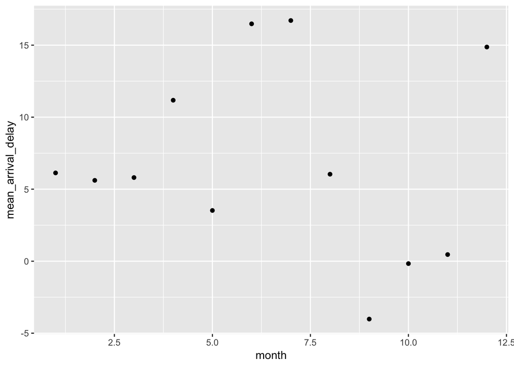

```r
# Pipe the results directly into ggplot
library(ggplot2)

group_by(flights, month) %>%
  summarize(number = n(),
            mean_distance = mean(distance, na.rm = TRUE),
            mean_arrival_delay = mean(arr_delay, na.rm = TRUE)) %>%
  ggplot(data = ., aes(x = month, y = mean_arrival_delay)) + geom_point()
```

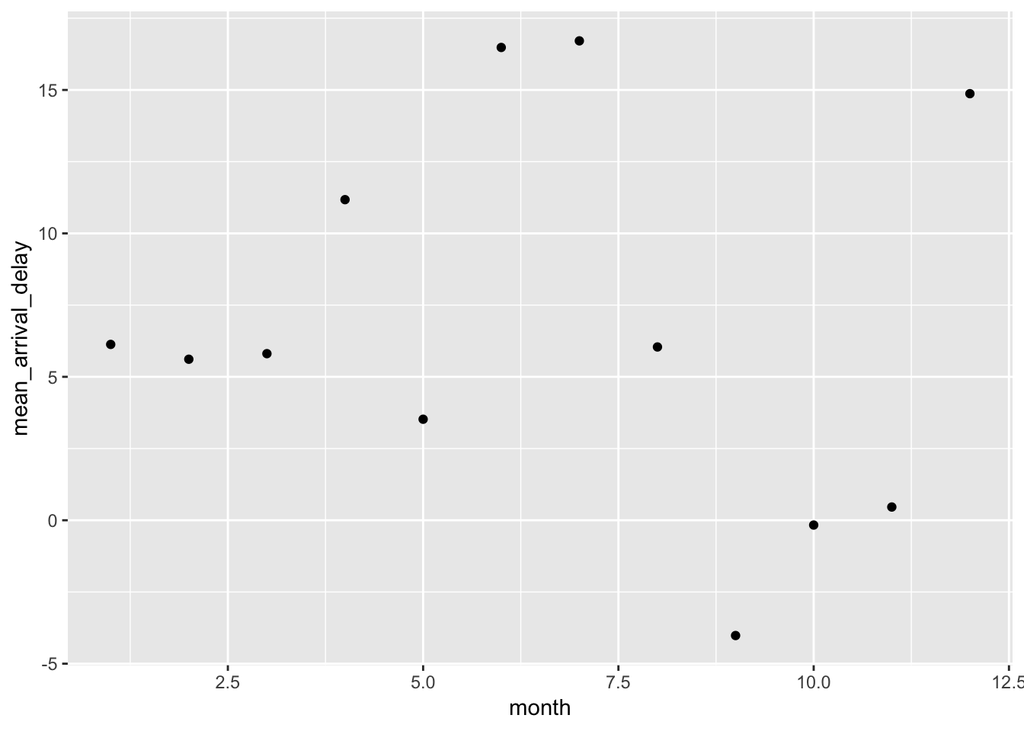

```r
# Save the results in "delays" and then use ggplot on delays
delays <- group_by(flights, month) %>%
  summarize(number = n(),
            mean_distance = mean(distance, na.rm = TRUE),
            mean_arrival_delay = mean(arr_delay, na.rm = TRUE))

ggplot(data = delays, aes(x = month, y = mean_arrival_delay)) + geom_point()
```

**Create a data frame which gives the number of flights and the mean arrival delay for flights on the carrier UA (United Airlines) whose destination is O’Hare Airport (ORD), with the number of flights and mean arrival delay calculated separately for flights out of each of the `origin` airports. (Hint: You’ll probably want to use `filter` first to get the UA flights whose destination is ORD, then group by the originating airport, then calculate the statistics requested.)**

```r
# Answer here...
```